# Decoding Chess Strategies

```python
%%HTML
<script src="require.js"></script>
```

```python
from IPython.display import HTML
HTML('''<script src="https://cdnjs.cloudflare.com/ajax/libs/jquery/2.0.3/jquery.min.js "></script><script>
code_show=true;
function code_toggle() {
if (code_show){
$('div.jp-CodeCell > div.jp-Cell-inputWrapper').hide();
} else {
$('div.jp-CodeCell > div.jp-Cell-inputWrapper').show();
}
code_show = !code_show
}
$( document ).ready(code_toggle);</script><form action="javascript:code_toggle()"><input type="submit" value="Toggle on/off for raw code"></form>
''')
```

[figure not shown]

## Abstract

The purpose of this initiative is to leverage categorical data clustering to uncover patterns in chess openings which could enhance chess players' strategic development and adaptability. It also aims to address the reliance of many players on a limited set of familiar opening moves, which hampers strategic growth and diminishes competitiveness within the chess community.

The methodology involved cleaning and preprocessing the dataset from chess.com, extracting relevant features, and applying categorical data clustering algorithm, particularly k-modes, on the entire dataset to identify patterns in player strategies. The resulting clusters will then be analyzed to provide insights into strategic preferences and common opening moves.

After a thorough analysis of the results, the team was able to identify 3 clusters from the entire dataset. Cluster 1, termed "Black's Defensive Grounds" (mostly 2400-2600 ELO), includes popular openings like Queen's Gambit Declined and Queen's Pawn Game, highlighting balanced play with strong defense and counter-attacks. Cluster 2, "Mid-Rated White Dominance" (mostly 2600-2800 ELO), features openings such as the Reti Opening and English Opening, characterized by aggressive play and frequent white wins. Cluster 3, "High-Rated Black Counters" (mostly 2800-3000 ELO), includes openings like the Irregular Opening and Queen's Gambit Declined, noted for effective defensive play and high black wins.

The team recognized that most of the matches involve players in the 2400-3000 ELO range, finding it difficult to analyze the clustering of lower ELO ratings from the entire dataset, which are more relevant to many, including club and class players. To address this gap, a targeted analysis was conducted for the ELO rating group of 1600-2400. This approach allowed us to explore the most effective and popular openings among players in this ELO rating range, providing insights that can help them improve their game. Cluster 1, "Versatile Strategies" (1600-2400 ELO), includes openings like the Irregular Opening and Caro-Kann Defense, emphasizing aggressive play and strategic depth. Cluster 2, "Black’s Balanced Defense" (1600-2400 ELO), features openings such as the French Defense and Sicilian Defense, focusing on effective defensive strategies and gradual control. Finally, Cluster 3, "Black Counters" (1600-2400 ELO), includes openings like the Reti Opening and Pirc Defense, highlighting strong defensive setups and counter-attack potential.

The results revealed distinct clusters of openings based on player ELO ratings, highlighting strategic preferences across different skill levels. Higher-rated players favor balanced strategies, while mid-level players exhibit a preference for aggressive openings. Notable findings include the consistency of certain openings across clusters and differences in play styles between high and mid-level players.

Recommendations include incorporating diverse datasets, analyzing strategies across different game formats, and enhancing data granularity by including opening moves. By addressing limitations and implementing improvements, future studies can provide valuable insights into chess strategy development, benefiting players of all levels.

Overall, this project succeeded in implementing categorical clustering which offered valuable insights into the strategic underpinnings of chess openings, catering to players of diverse skill levels. By decoding these patterns and highlighting the effectiveness of various openings, it equips players with the knowledge to refine their repertoire and enhance their gameplay. Ultimately, this endeavor will foster a more competitive and dynamic chess environment, driving continuous improvement and innovation within the chess community.

## Introduction

Chess, a game with a rich history dating back over a thousand years, continues to captivate players worldwide with its strategic depth and intellectual challenges. As of 2024, the global chess community boasts an estimated 605 million active players, showcasing its widespread relevance and appeal [[1]](https://www.chess.com/news/view/how-popular-is-chess-8306). Central to mastering this venerable game is understanding chess opening strategy, an area that remains immutable in terms of rules yet evolves in gameplay and sophistication.

The opening phase of a chess game involves the development of pieces from their initial positions. The primary goals are to control the center of the board, develop pieces effectively, ensure the safety of the king, and prepare for the ensuing middlegame. Despite the constancy of these objectives and the unchanging rules of chess, the strategies employed by players have grown increasingly complicated. Advancements in theory, analysis, and the sharing of knowledge have greatly enhanced the quality of play, allowing players to avoid early pitfalls and position themselves favorably for the middle phase of the game.

The advent of online platforms like Chess.com has brought significant changes to how chess is played and learned. Moving from physical boards to digital interfaces, players now have unprecedented access to a wealth of resources including databases of games, analysis tools, and real-time matches against opponents from around the world. This shift has democratized learning and competition, enabling players of all skill levels to improve their game more rapidly and engage with a global community. Whether one is a beginner learning the ropes or an advanced player honing their strategy, the essence of chess remains the same, but the way it is played continues to evolve with technology.

## Problem Statement

Most chess players often rely on a limited set of familiar opening moves, which can hinder their strategic development and adaptability in games. This limitation not only affects individual player performance but also diminishes the overall diversity and competitiveness within the chess community. To address this critical issue, this project aims to:

1. *Cluster matches based on chess openings.* By applying categorical clustering techniques on the entire dataset of historical game data, we can identify distinct clusters of chess openings. This approach involves categorizing the data based on the opening moves used by players, enabling us to uncover patterns and group similar opening strategies. The objective is to identify clusters that represent both commonly used and underexplored openings. This categorization will facilitate targeted strategy recommendations, helping players to expand their strategy beyond their familiar openings.
2. *Analyze the Clusters to Identify Patterns and Key Insights.* Once the clusters are formed, the next step is to conduct a detailed analysis of each cluster to extract meaningful patterns and key insights. This analysis aims to understand the strategic preferences and effectiveness of different opening moves within each cluster. By identifying the strengths and weaknesses associated with various openings, we can provide players with actionable insights that enhance their strategic development. These insights will help players diversify their opening strategies, improve their adaptability in games, and ultimately contribute to a more competitive and diverse chess community.

By leveraging categorical data clustering techniques to uncover patterns and suggest novel and effective openings tailored to individual players' styles and preferences, we can drive significant improvements in strategic variety and player adaptability. This, in turn, will enhance the competitive landscape, promote continuous learning, and elevate the overall standard of play in the chess community.

## Motivation

The significance of chess extends beyond its status as a timeless game. The sport is highly competitive, with over 1,700 grandmasters recognized by the World Chess Federation (FIDE) as of 2020 [[2]](https://www.fide.com/news/782), reflecting the high level of skill and dedication within the community. This participation from the competitive and casual payers of the chess community underscores the necessity for continuous advancement in chess strategies and player development, ensuring that players at all levels can enhance their competitive edge and contribute to the vibrant and evolving landscape of chess.

From an economic standpoint, chess contributes substantially to the competitive sports industry. The FIDE World Chess Championship 2024, one of the pinnacle events in the chess calendar, offers a prize fund of USD2.5 million, while the total budget for the event is USD8.5 million, including a USD1.1 million fee to FIDE [[3]](https://www.business-standard.com/sports/other-sports-news/fide-opens-bidding-process-for-world-championship-sets-budget-of-9-6-mn-124042700604_1.html). Additionally, the FIDE Chess Olympiad, often referred to as the "Olympics of Chess," features numerous top players from around the world, highlighting the game's global reach and competitive spirit. This event attracts sponsorships, broadcasting deals, and commercial partnerships, further elevating the game's market value.

Moreover, platforms like Chess.com have seen exponential growth, reaching over 100 million members by the end of 2022 [[4]](https://www.chess.com/article/view/chesscom-reaches-100-million-members) and even experiencing a server crash due to heavy traffic, accumulating more than 10 million active players in a single day [[5]](https://esports.gg/news/chess/chess-com-crashes-as-it-hits-the-highest-ever-daily-active-users/). This surge reflects the growing interest and engagement in chess, fueled by digital accessibility and popular media portrayals, such as "The Queen's Gambit." The digital transformation of chess has opened new avenues for players to learn, compete, and improve their skills, thereby fostering a more competitive and vibrant chess community.

The motivation behind this project is to leverage advanced data clustering techniques to analyze and categorize chess openings and ultimately, provide players with insights that can diversify their strategies and enhance their adaptability. This, in turn, will promote strategic growth, reduce reliance on a narrow set of familiar openings, and ultimately contribute to a more dynamic and competitive chess environment.

This initiative not only addresses the strategic development of individual players but also supports the broader chess community by fostering innovation, diversity in play, and continuous improvement. By doing so, it aligns with the evolving landscape of competitive chess, benefiting both amateurs and professionals and enhancing the overall quality and excitement of the game.

## Preliminaries

### Clustering Methods

**Categorical Clustering Using K-Modes**  
K-Modes is an extension of the K-Means algorithm tailored for categorical data. Unlike K-Means, which uses the mean for cluster centroids and Euclidean distance for distance calculation, K-Modes uses modes for centroids and a simple matching dissimilarity measure (i.e., the number of mismatches between two categorical objects). It is efficient for large datasets and works well with purely categorical data.

**Categorical Clustering Using K-Medoids**  
K-Medoids is another clustering algorithm that is particularly useful for categorical data. It is more robust than K-Means because it uses medoids (actual data points) as cluster centers instead of centroids, which can be heavily influenced by outliers. The computational complexity of K-Medoids is significantly higher than K-Modes because:

- It involves calculating the distance between every pair of data points in each iteration, which leads to an (O(k(n-k)^2)) time complexity, where (n) is the number of data points and (k) is the number of clusters.
- The update step requires examining all possible medoids within each cluster, further increasing computational cost.
- This makes K-Medoids computationally expensive and less scalable for large datasets.

Due to its high computational complexity and limitation of computing capacity, K-Medoids wasn't able to finish at all when dealing with the extensive chess dataset.

### Definition of Terms

1. ELO - Rating system used in Chess. Table 1 below shows the corresponding titles given to each ELO rating range. The titles of Grandmaster, International Master, FIDE Master and Candidate Master are official chess titles awarded to players by Fédération Internationale des Échecs(FIDE). The requirements for each title have varied over time, but generally require having demonstrated a prescribed level of achievement in tournaments at classical time controls under FIDE-approved conditions. [[6]](https://www.chess.com/blog/praharshkstudios/all-the-chess-titles-and-how-to-acquire-them#:~:text=There%20are%208%20official%20chess%20titles%20awarded%20to,CM%2C%20FM%2C%20IM%20and%20GM%20in%20that%20order.)

**Table 1. ELO Rating System in Chess**

| Rating Range | Title |
| --- | --- |
| ≥ 2500 | Grandmaster |
| 2400 - 2499 | International Master |
| 2300 - 2399 | FIDE Master |
| 2200 - 2299 | FIDE Candidate Master/National Master |
| 2000 - 2199 | Expert/National Candidate Master |
| 1800 - 1999 | Class A Player |
| 1600 - 1799 | Class B Player |
| 1400 - 1599 | Class C Player |
| 1200 - 1399 | Class D Player |
| 1000 - 1199 | Class E Player |

2. ECO - Encyclopedia of Chess Openings. ECO Codes is the classification system for chess opening moves (e.g. Queen’s Gambit: D06 - D69)[[7]](https://www.365chess.com/eco.php).

## Import Libraries and Define File Paths

```python
# IMPORT LIBRARIES
from kmodes.kmodes import KModes
from IPython.display import display
import pandas as pd
import numpy as np
import matplotlib.pyplot as plt
import requests
import seaborn as sns
import warnings

# Suppress warnings
warnings.filterwarnings('ignore')


# Define a function to calculate cost for a given k
def calculate_cost_kmodes(k, samples):
    """Calculate cost for kmodes given k."""
    return KModes(k).fit(samples).cost_


def calculate_cost(df, n):
    """Calculate costs for set of ks."""
    kmodes_cost = []
    for k in ks:
        samples = df.sample(n)
        kmodes_cost.append(calculate_cost_kmodes(k, samples))
    return kmodes_cost


def plot_costs(kmodes_cost, k, x):
    """Plot cost for kmodes."""
    # Plot the results
    plt.plot(ks, kmodes_cost, '-o')
    plt.ylim(ymin=0)
    plt.xlabel('$k$')
    plt.ylabel('cost')
    plt.figtext(0.5, -0.04, f'Figure {x}. Cost Plot for K-Modes',
                ha='center', fontsize=12)
    plt.axvline(x=k, color='r', linestyle='--')
    plt.show()


def create_df_clusters(model, df):
    """Create DataFrame with clusters given model."""
    df_clusters = df.copy()
    df_clusters['cluster'] = km.fit_predict(df_clusters)
    return df_clusters


def print_stats_per_cluster(df_clusters, n=5):
    """Print statistics per cluster."""
    cluster_groups = df_clusters.groupby('cluster')
    # Iterate over each cluster
    for cluster, cluster_df in cluster_groups:
        display(cluster_df.drop(columns=['cluster']).describe())
        print(f"Top {n} ECO for cluster {cluster}:")
        display(pd.DataFrame(
            cluster_df['ECO'].value_counts().head(n)))
        print()
        # print(f"Top {n} Openings for cluster {cluster}:")
        # display(pd.DataFrame(
        #     cluster_df['Opening'].value_counts().head(n)))
        # print()
        # print()
        # print(f"Top {n} (White Win) ECO for cluster {cluster}:")
        # display(pd.DataFrame(
        #     cluster_df[cluster_df['Result'] == '1-0']
        #     ['ECO'].value_counts().head(n)))
        # print()
        # print(f"Top {n} (White Win) Openings for cluster {cluster}:")
        # display(pd.DataFrame(
        #     cluster_df[
        #     cluster_df['Result'] == '1-0']
        #     ['Opening'].value_counts().head(n)))
        # print()
        # print()
        # print(f"Top {n} (Black Win) ECO for cluster {cluster}:")
        # display(
        #     pd.DataFrame(
        #         cluster_df[
        #         cluster_df['Result'] == '0-1']
        #         ['ECO'].value_counts().head(n)))
        # print()
        # print(f"Top {n} (Black Win) Openings for cluster {cluster}:")
        # display(
        #     pd.DataFrame(
        #         cluster_df[
        #         cluster_df['Result'] == '0-1']
        #         ['Opening'].value_counts().head(n)))
        # print()
        # print()


def plot_top_eco_codes(cluster_number, title):
    """
    Plot the top 5 ECO codes for a specified cluster.
    """
    # Filter data for the specified cluster
    cluster_data = (
        df_clusters_kmodes[df_clusters_kmodes['cluster'] == cluster_number]
    )

    # Get the top 5 ECO codes for the cluster
    top_eco_codes = cluster_data['ECO'].value_counts().head(5)

    # Create a bar chart
    plt.figure(figsize=(10, 6))
    bars = plt.bar(
        top_eco_codes.index,
        top_eco_codes.values,
        color='#A7C957',
        edgecolor='black')

    # Add labels and title
    plt.xlabel('ECO Code')
    plt.ylabel('Number of Games')

    plt.figtext(0.5, 0, title,
                ha='center', fontsize=12)

    # Hide y-axis and remove the box
    plt.gca().spines['top'].set_visible(False)
    plt.gca().spines['right'].set_visible(False)
    plt.gca().spines['left'].set_visible(False)
    plt.gca().spines['bottom'].set_visible(True)
    plt.gca().yaxis.set_visible(False)

    # Add data labels
    for bar in bars:
        yval = bar.get_height()
        plt.text(
            bar.get_x() + bar.get_width() / 2,
            yval + 50, int(yval),
            ha='center',
            va='bottom',
            fontsize=10)

    # Show the plot
    plt.show()


def add_percentage_labels(bars, percentages):
    for bar, percentage in zip(bars, percentages):
        plt.text(
            bar.get_x() + bar.get_width() / 2,
            bar.get_height() / 2 + bar.get_y(),
            f'{percentage:.1f}%',
            ha='center',
            va='center',
            color='white',
            fontsize=10
        )


def plot_win_distribution(cluster_number, title):
    """Plot the win distribution of each cluster"""
    # Filter data for the specified cluster
    cluster_data = (
        df_clusters_kmodes[df_clusters_kmodes['cluster'] == cluster_number])

    # Get the top 5 most popular ECO codes in the cluster
    top_eco = cluster_data['ECO'].value_counts().head(5).index
    top_eco_data = cluster_data[cluster_data['ECO'].isin(top_eco)]

    # Calculate win distribution percentages for each ECO code
    win_distribution = (
        top_eco_data.groupby('ECO')['Result'].value_counts(
            normalize=True).unstack().fillna(0) * 100)

    # Create a figure
    plt.figure(figsize=(10, 6))

    # Plot stacked bars with updated colors
    bar1 = plt.bar(win_distribution.index, win_distribution['1-0'],
                   color='#A7C957',
                   label='White Wins')
    bar2 = plt.bar(win_distribution.index, win_distribution['0-1'],
                   bottom=win_distribution['1-0'],
                   color='#4A7C59',
                   label='Black Wins')
    bar3 = plt.bar(win_distribution.index, win_distribution['1/2-1/2'],
                   bottom=win_distribution['1-0'] + win_distribution['0-1'],
                   color='#C8C8C8',
                   label='Draws')

    # Add labels and title
    plt.xlabel('ECO Code')
    plt.ylabel('Percentage')
    plt.legend()

    plt.figtext(0.5, -0.02, title,
                ha='center',
                fontsize=12)

    # Function to add labels as percentages
    def add_percentage_labels(bars, percentages):
        for bar, percentage in zip(bars, percentages):
            plt.text(
                bar.get_x() + bar.get_width() / 2,
                bar.get_height() / 2 + bar.get_y(),
                f'{percentage:.1f}%',
                ha='center',
                va='center',
                color='white',
                fontsize=10
            )

    # Add labels as percentages
    add_percentage_labels(bar1, win_distribution['1-0'].values)
    add_percentage_labels(bar2, win_distribution['0-1'].values)
    add_percentage_labels(bar3, win_distribution['1/2-1/2'].values)

    # Hide y-axis and remove the box
    plt.gca().spines['top'].set_visible(False)
    plt.gca().spines['right'].set_visible(False)
    plt.gca().spines['left'].set_visible(False)
    plt.gca().spines['bottom'].set_visible(True)
    plt.gca().yaxis.set_visible(False)

    # Adjust layout to remove margins
    plt.subplots_adjust(left=0.1, right=0.9, top=0.9, bottom=0.1)

    # Display the plot
    plt.show()
```

**Global Libraries and Functions:**

**`import requests`**: This library makes HTTP requests to a specified URL and to interact with web services or to download data from websites.

**`from kmodes.kmodes import KModes`**: This class implements the k-modes clustering algorithm, suitable for clustering categorical variables.

**`import pandas as pd`**: This library provides extensive data structures and data analysis tools, which make data cleaning, analysis, and visualization easier.

**`import numpy as np`**: This library is fundamental for scientific computing with Python, providing support for large, multi-dimensional arrays and matrices, along with a large collection of high-level mathematical functions to operate on these arrays.

**`import matplotlib.pyplot as plt`**: This library provides an object-oriented API for embedding plots into applications using general-purpose GUI toolkits like Tkinter, wxPython, Qt, or GTK.

**`import seaborn as sns`** This library isdata visualization library based on Matplotlib that provides a high-level interface for drawing attractive and informative statistical graphics.

### Utility and Dataset Generation Functions:

`calculate_cost_kmodes(k, samples):` : Function to calculate cost for a given k using the KModes algorithm

`calculate_cost(df, n):` : Function to calculate and store costs for a series of k values for KModes clustering

`plot_costs(costs, k, x):` : Function to plot costs against the number of clusters k. The parameter x is used for the figure label.

`create_df_clusters(model, df):` : Function to create a new DataFrame including cluster labels

`print_stats_per_cluster(df_clusters, n=5):` : Function to print statistics for each cluster, such as top ECO codes and opening moves

`plot_win_distribution(cluster_number)`: Function ensure that `df_clusters_kmodes` is a DataFrame that contains the columns `cluster`, `ECO`, and `Result`.

## Methodology

This study applied the methodology pipeline described in Figure 1 below. This section discusses the tasks performed for each step in detail.

### Methodology Overview

[figure not shown]

**Figure 1: Methodology Overview**

### Methodology Details

1. To gather this dataset, web scraping techniques were employed to extract game data from Chess.com using their API.
   - Utilizing the Chess.com Data API to fetch game details.
   - Parsing JSON responses to extract relevant features.
   - Storing the extracted data in a structured format (CSV).
2. Clean and preprocess the dataset, handling missing values and encoding categorical variables such as ECO codes and player IDs.
3. Extract relevant categorical features, including player IDs, opening moves, and game outcomes, to create a feature matrix suitable for clustering.
4. Apply a categorical data clustering algorithm, in this case k-modes, on the entire dataset to categorize matches based on chess openings.
5. Analyze the resulting clusters to uncover patterns and categorize chess openings to provide players with insights that can diversify their strategies and enhance their adaptability.
6. Provide conclusion and recommendations for future works as well as future users and stakeholders.

```python
# The url is not complete as it will reviel the owner of the key. We suggest
# to add "https://api.chess.com/pub/player/your_service_account/stats"
# API endpoint
url = 'https://api.chess.com/pub/player/'

# Request headers
headers = {
    'User-Agent': 'Mozilla/5.0 (Windows NT 10.0; Win64; x64) AppleWebKit/537.36 (KHTML, like Gecko) Chrome/96.0.4664.93 Safari/537.36'
}

# Making the GET request
response = requests.get(url, headers=headers)
```

## List of Tables

- Table 1. ELO Rating System in Chess
- Table 2. Players with the Highest ELO Rating
- Table 3. Top Players in White per ELO Rating Range
- Table 4. Top Players in Black per ELO Rating Range

## Data Source

### Data Description

The dataset comprises historical game data from Chess.com, including:

- This includes unique user IDs of players, as well as their WhiteElo and BlackElo ratings, which provide an indication of the players' skill levels when playing as white or black.
- Each game is detailed with information such as the event type (e.g., tournament, casual game), and the time control setting (e.g., blitz, rapid, classical).
- The dataset records the opening moves used in each game, identified by ECO (Encyclopedia of Chess Openings) codes.
- Results of the games are recorded as win, loss and draw. This helps in assessing the effectiveness of different opening moves.
- Additional Metadata - General metadata elements provide more context and granularity to the data, aiding in clustering.

### Data Collection

The dataset for this analysis was collected by scraping chess.com using the chess.com API. Here are the details of the data collection process:

1. **Source**: Chess.com, one of the largest and most popular online chess platforms, was used as the data source. The platform hosts a vast number of games played by users of varying skill levels from around the world.
2. **API Access**: The chess.com API provides programmatic access to the site's vast database of games. This API allows users to retrieve information about individual games, player statistics, and opening moves among other data.
3. **Scraping Process**: The data scraping process involved making API calls to retrieve game records. This process was automated using scripts that systematically collected data over a period of time.
4. **Data Points Collected**:
   - **Game Metadata**: Information about each game such as game ID, players involved, ratings, time controls, and result.
   - **Move Sequences**: Detailed move sequences for each game, including the opening moves which were crucial for determining the ECO codes.
   - **Outcome Data**: Results of each game indicating whether the game was a win for white, a win for black, or a draw.
   - **Timestamps**: The date and time when each game was played to analyze trends over time.

By leveraging the chess.com API, the data collection process ensured a comprehensive and representative sample of chess games, providing a robust foundation for analyzing opening strategies and their effectiveness.

#### Legality of the Dataset

The collected data and information available to users who are not logged in include player data, game data, and club/tournament information. This excludes private information, which is restricted to logged-in users, such as game chat and conditional moves. This data is read-only; users cannot send game moves or other commands to Chess.com from this system.

## Data Generation and Preprocessing

This section presents the critical steps taken to prepare our dataset for effective clustering analysis. This phase is essential for ensuring data quality and integrity, which directly impact the reliability of our clustering results. We detail the procedures used to gather, clean, and preprocess the chess game data obtained from chess.com, focusing on transforming raw data into a structured format suitable for analysis.

### Load the Dataset

```python
matches = pd.read_csv('matches 2.csv')
matches.head()
```

|  | Unnamed: 0 | Event | Site | Date | Round | White | Black | Result | CurrentPosition | Timezone | ... | EndTime | Link | Moves | Tournament | Variant | SetUp | FEN | Opening | Won | Match |
| --- | --- | --- | --- | --- | --- | --- | --- | --- | --- | --- | --- | --- | --- | --- | --- | --- | --- | --- | --- | --- | --- |
| 0 | 0 | Live Chess | Chess.com | 2014.09.07 | - | 123lt | kingbos-inactive | 1-0 | r5k1/3R4/p1p3pB/5p2/2P4P/6P1/PP6/6K1 w - - | UTC | ... | 03:15:08 | https://www.chess.com/game/live/907775078 | 1. d4 {[%clk 0:02:00]} 1... d5 {[%clk 0:02:01]... | NaN | NaN | NaN | NaN | Queens-Gambit-Declined-Albin-Countergambit-3.d... | True | NaN |
| 1 | 1 | Live Chess | Chess.com | 2014.09.07 | - | betablokator | 123lt | 0-1 | 4Q3/5pkp/4p1p1/8/4q3/7P/3r3K/6R1 w - - | UTC | ... | 03:18:59 | https://www.chess.com/game/live/907776561 | 1. e4 {[%clk 0:02:00]} 1... c5 {[%clk 0:02:00]... | NaN | NaN | NaN | NaN | Sicilian-Defense-McDonnell-Attack-2...d5-3.e5 | True | NaN |
| 2 | 2 | Live Chess | Chess.com | 2014.09.07 | - | Computer3-HARD | 123lt | 0-1 | 1K6/q1r5/5k2/8/8/8/8/8 w - - | UTC | ... | 03:23:36 | https://www.chess.com/game/live/907778789 | 1. d4 {[%clk 0:02:00]} 1... d5 {[%clk 0:02:00]... | NaN | NaN | NaN | NaN | Slav-Defense-3.Nc3-Nf6 | True | NaN |
| 3 | 3 | Live Chess | Chess.com | 2014.09.07 | - | 123lt | Computer3-HARD | 1/2-1/2 | 8/7k/8/5K2/8/8/8/8 w - - | UTC | ... | 03:26:27 | https://www.chess.com/game/live/907780547 | 1. e4 {[%clk 0:02:00]} 1... e5 {[%clk 0:02:00]... | NaN | NaN | NaN | NaN | Philidor-Defense | False | NaN |
| 4 | 4 | Live Chess | Chess.com | 2014.09.07 | - | Computer3-HARD | 123lt | 1-0 | r1b2r1k/1q1nNpbp/2P3p1/p2N4/1P2p3/4P3/2PB1PPP/... | UTC | ... | 03:27:32 | https://www.chess.com/game/live/907781986 | 1. d4 {[%clk 0:02:00]} 1... d5 {[%clk 0:02:00]... | NaN | NaN | NaN | NaN | Queens-Pawn-Opening-1...d5-2.e3-e6-3.Bd3 | False | NaN |

5 rows × 30 columns

### Handle Irrelevant Columns

For simplicity, only Live Chess games will be included in the data clustering analysis. To ensure that the dataset is appropriately structured for categorical clustering, several columns that are irrelevant to the clustering process are dropped. These columns are as follows:

- `Unnamed: 0`: This is typically an index column that is automatically generated and does not contain meaningful data.
- `Event`, `Site`, `Round`, `CurrentPosition`: These columns pertain to specific details about the game event and location, which are not relevant for identifying patterns in player strategies.
- `Timezone`, `ECOUrl`, `UTCDate`, `UTCTime`: These columns contain temporal and web link information that do not contribute to the clustering based on player strategies.
- `TimeControl`, `Termination`, `StartTime`, `EndDate`, `EndTime`: While these columns describe the timing and conclusion of games, they do not directly influence the categorical analysis of strategies.
- `Link`, `Moves`, `Tournament`, `Variant`, `SetUp`, `FEN`, `Match`: These columns provide links, detailed move sequences, and other metadata that are not needed for the clustering algorithm. The 'Moves' column, for example, would require a different type of analysis focused on sequence patterns rather than categorical clustering.
- `Won`: Redundant with the Result column.

By dropping these columns, we streamline the dataset to focus on the most relevant features for categorical clustering, thereby enhancing the efficiency and clarity of the analysis aimed at identifying distinct player strategies based on chess openings.

### Bin ELO Ratings

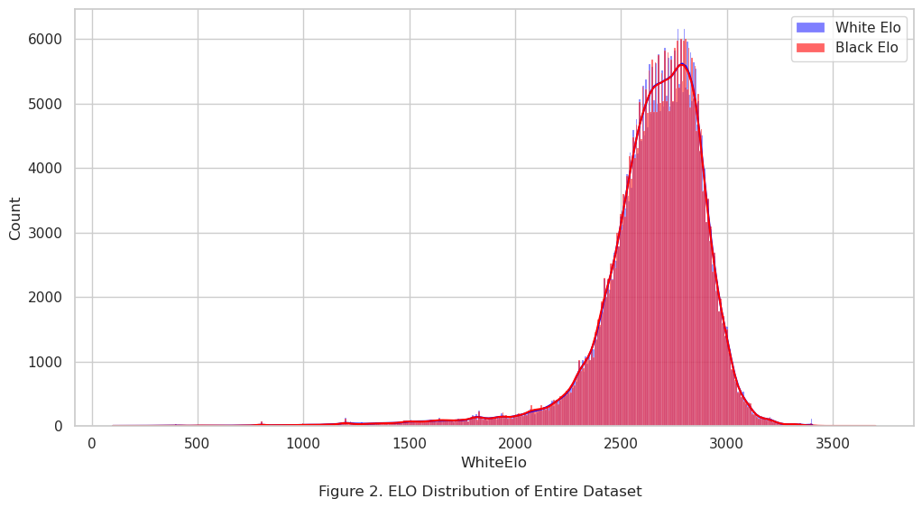

```python
# Setting aesthetic parameters in one step
sns.set(style="whitegrid")

# Elo ratings distribution
plt.figure(figsize=(12, 6))
sns.histplot(data=matches, x='WhiteElo', color='blue',
             kde=True, label='White Elo')
sns.histplot(data=matches, x='BlackElo', color='red',
             kde=True, label='Black Elo', alpha=0.6)
plt.figtext(
    0.5, -0.02, 'Figure 2. ELO Distribution of Entire Dataset',
    ha='center', fontsize=12)
plt.legend()
plt.show()
```

The choice to begin binning at a rating of 1600 for competitive matches is based on the standard that a rating of 1600 often marks the transition from casual to more serious, competitive play. Players at this level have typically mastered fundamental chess skills and strategies, making it an appropriate starting point for categorizing higher levels of play. This rating threshold helps ensure that the competitive matches involve players who are comparably skilled and serious about their gameplay, thus maintaining a higher standard of match quality and competitiveness. Filtering for "Live Chess" in the dataset focuses the analysis on real-time games, which constitute the majority of the data and are likely to exhibit consistent behaviors and strategies. This approach simplifies the analysis, enhances computational efficiency, and provides insights that are more relevant to the dynamics of live chess play.

```python
# Filter only the Live Chess for simplicity.
matches = matches[matches['Event'] == 'Live Chess']
columns_to_drop = [
    'Unnamed: 0', 'Event', 'Site', 'Round', 'CurrentPosition',
    'Timezone', 'ECOUrl', 'UTCDate', 'UTCTime', 'TimeControl',
    'Termination', 'StartTime', 'EndDate', 'EndTime', 'Link',
    'Moves', 'Tournament', 'Variant', 'SetUp', 'FEN', 'Match', 'Won']

matches.drop(columns=columns_to_drop, inplace=True)
matches.dropna(inplace=True)

# Filter to include only rows where both
# WhiteElo and BlackElo are 1600 and above
matches = matches[(matches['WhiteElo'] >= 1600) &
                  (matches['BlackElo'] >= 1600)]
```

```python
# Create bins for different Elo rating ranges
bins = [1600, 1800, 2000, 2200, 2400, 2600, 2800, 3000, 3200, 3400, 5000]
matches['white_rating_group'] = pd.cut(matches['WhiteElo'], bins=bins)
matches['black_rating_group'] = pd.cut(matches['BlackElo'], bins=bins)
```

```python
matches
```

|  | Date | White | Black | Result | ECO | WhiteElo | BlackElo | Opening | white_rating_group | black_rating_group |
| --- | --- | --- | --- | --- | --- | --- | --- | --- | --- | --- |
| 13 | 2014.09.07 | 123lt | YRframe | 1-0 | D02 | 1657.0 | 1694.0 | Queens-Pawn-Opening-Zukertort-Variation-2...c6... | (1600, 1800] | (1600, 1800] |
| 17 | 2014.09.07 | 123lt | Robercik512 | 1-0 | A41 | 1788.0 | 1661.0 | Queens-Pawn-Opening-Anglo-Slav-Opening-3.Nc3 | (1600, 1800] | (1600, 1800] |
| 18 | 2014.09.07 | 123lt | Computer4-IMPOSSIBLE | 1/2-1/2 | E00 | 1687.0 | 2358.0 | Indian-Game-East-Indian-Defense | (1600, 1800] | (2200, 2400] |
| 19 | 2014.09.07 | Computer4-IMPOSSIBLE | 123lt | 1-0 | A45 | 2358.0 | 1685.0 | Trompowsky-Attack-Classical-Defense-3.Nd2-d5-4... | (2200, 2400] | (1600, 1800] |
| 20 | 2014.09.07 | 123lt | Computer4-IMPOSSIBLE | 0-1 | B13 | 1683.0 | 2358.0 | Caro-Kann-Defense-Exchange-Variation-3...cxd5-... | (1600, 1800] | (2200, 2400] |
| ... | ... | ... | ... | ... | ... | ... | ... | ... | ... | ... |
| 376326 | 2024.02.03 | ArcticBear64 | SeanWinshand | 1-0 | D07 | 3112.0 | 2889.0 | Queens-Gambit-Declined-Chigorin-Main-Line...8.... | (3000, 3200] | (2800, 3000] |
| 376327 | 2024.02.03 | SeanWinshand | ArcticBear64 | 1-0 | D00 | 2902.0 | 3099.0 | Queens-Pawn-Opening-Accelerated-London-System-... | (2800, 3000] | (3000, 3200] |
| 376328 | 2024.02.03 | ArcticBear64 | SeanWinshand | 1-0 | D02 | 3103.0 | 2898.0 | Queens-Pawn-Opening-Zukertort-Chigorin-Variation | (3000, 3200] | (2800, 3000] |
| 376329 | 2024.02.03 | artooon | ArcticBear64 | 1-0 | B90 | 3056.0 | 3094.0 | Sicilian-Defense-Open-Najdorf-Variation-6.Bd3 | (3000, 3200] | (3000, 3200] |
| 376330 | 2024.02.03 | ArcticBear64 | artooon | 0-1 | D55 | 3085.0 | 3065.0 | Queens-Gambit-Declined-Neo-Orthodox-Variation | (3000, 3200] | (3000, 3200] |

362531 rows × 10 columns

```python
# matches.columns
```

### Handle Missing Values

`matches.dropna(inplace=True)` is used to handle missing values in a DataFrame. We remove all rows in the `matches` DataFrame that contain any missing values in any column.

```python
matches.dropna(inplace=True)
matches
```

|  | Date | White | Black | Result | ECO | WhiteElo | BlackElo | Opening | white_rating_group | black_rating_group |
| --- | --- | --- | --- | --- | --- | --- | --- | --- | --- | --- |
| 13 | 2014.09.07 | 123lt | YRframe | 1-0 | D02 | 1657.0 | 1694.0 | Queens-Pawn-Opening-Zukertort-Variation-2...c6... | (1600, 1800] | (1600, 1800] |
| 17 | 2014.09.07 | 123lt | Robercik512 | 1-0 | A41 | 1788.0 | 1661.0 | Queens-Pawn-Opening-Anglo-Slav-Opening-3.Nc3 | (1600, 1800] | (1600, 1800] |
| 18 | 2014.09.07 | 123lt | Computer4-IMPOSSIBLE | 1/2-1/2 | E00 | 1687.0 | 2358.0 | Indian-Game-East-Indian-Defense | (1600, 1800] | (2200, 2400] |
| 19 | 2014.09.07 | Computer4-IMPOSSIBLE | 123lt | 1-0 | A45 | 2358.0 | 1685.0 | Trompowsky-Attack-Classical-Defense-3.Nd2-d5-4... | (2200, 2400] | (1600, 1800] |
| 20 | 2014.09.07 | 123lt | Computer4-IMPOSSIBLE | 0-1 | B13 | 1683.0 | 2358.0 | Caro-Kann-Defense-Exchange-Variation-3...cxd5-... | (1600, 1800] | (2200, 2400] |
| ... | ... | ... | ... | ... | ... | ... | ... | ... | ... | ... |
| 376326 | 2024.02.03 | ArcticBear64 | SeanWinshand | 1-0 | D07 | 3112.0 | 2889.0 | Queens-Gambit-Declined-Chigorin-Main-Line...8.... | (3000, 3200] | (2800, 3000] |
| 376327 | 2024.02.03 | SeanWinshand | ArcticBear64 | 1-0 | D00 | 2902.0 | 3099.0 | Queens-Pawn-Opening-Accelerated-London-System-... | (2800, 3000] | (3000, 3200] |
| 376328 | 2024.02.03 | ArcticBear64 | SeanWinshand | 1-0 | D02 | 3103.0 | 2898.0 | Queens-Pawn-Opening-Zukertort-Chigorin-Variation | (3000, 3200] | (2800, 3000] |
| 376329 | 2024.02.03 | artooon | ArcticBear64 | 1-0 | B90 | 3056.0 | 3094.0 | Sicilian-Defense-Open-Najdorf-Variation-6.Bd3 | (3000, 3200] | (3000, 3200] |
| 376330 | 2024.02.03 | ArcticBear64 | artooon | 0-1 | D55 | 3085.0 | 3065.0 | Queens-Gambit-Declined-Neo-Orthodox-Variation | (3000, 3200] | (3000, 3200] |

```python
# matches['Date'].min()
```

```python
# matches['Date'].max()
```

### Exclude Matches that are Played Againts Computer Bots

Matches played against computer bots are excluded as a crucial step in the analysis of game data, where understanding human strategy and performance is the objective. Bots often operate at various predetermined difficulty the levels, which might not correspond to the natural skill levels of human players. Including these matches in performance analysis can distort assessments of a player’s true skill and improvement over time. We have applied filters in our data processing scripts or queries to exclude records where the opponent is flagged as a bot.

```python
# List of computer players to exclude (updated)
computer_players = ['PlayKomodo',
                    'Computer3-HARD',
                    'Computer4-MEDIUM',
                    'Computer5-EASY',
                    'Computer4-IMPOSSIBLE']

# Filter out games involving computer players
matches = (
    matches[~matches['White'].isin(
        computer_players) & ~matches['Black'].isin(computer_players)])

# Verify the filtering
# print(matches[['White', 'Black']].head())
```

## Data Exploration

This section provides a comprehensive examination of the dataset, serving as a crucial step in understanding and preparing the data for subsequent clustering. This phase involves detailed data inspection and visualization to uncover initial insights and patterns in chess openings. By examining the distribution of key features we identify potential relationships and anomalies that inform our clustering approach.

### Player Distribution

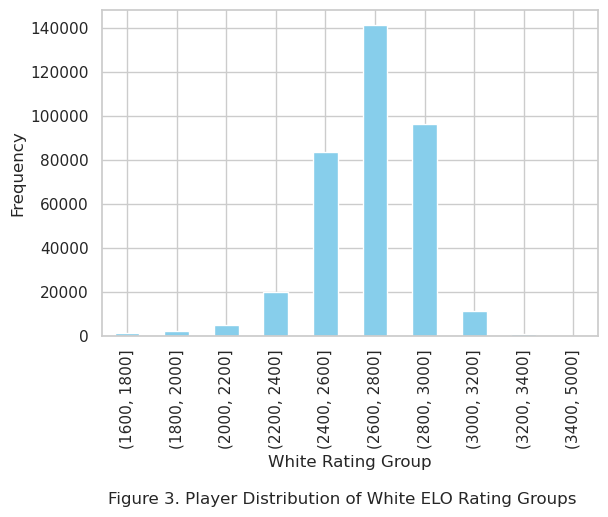

```python
matches['white_rating_group'].value_counts().sort_index().plot(
    kind='bar', color='skyblue')

# Adding titles and labels for clarity
# plt.title('Distribution of White Rating Groups', loc='center', pad=-20)
plt.xlabel('White Rating Group')
plt.ylabel('Frequency')

# Adjusting layout to make space for the bottom title
plt.subplots_adjust(bottom=0.2)

# Adding the plot title at the bottom center
plt.figtext(
    0.5, -0.15, 'Figure 3. Player Distribution of White ELO Rating Groups',
    ha='center',
    fontsize=12)

# Display the plot
plt.show()
```

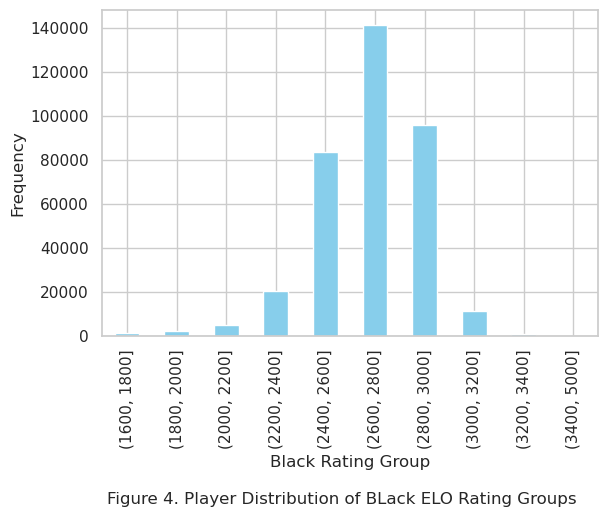

```python
matches['black_rating_group'].value_counts().sort_index().plot(kind='bar',
                                                               color='skyblue')

# Adding titles and labels for clarity
# plt.title('Distribution of White Rating Groups', loc='center', pad=-20)
plt.xlabel('Black Rating Group')
plt.ylabel('Frequency')

# Adjusting layout to make space for the bottom title
plt.subplots_adjust(bottom=0.2)

# Adding the plot title at the bottom center
plt.figtext(
    0.5, -0.15, 'Figure 4. Player Distribution of BLack ELO Rating Groups',
    ha='center',
    fontsize=12)

# Display the plot
plt.show()
```

Majority of players fall within the 2400 to 3000 rating range for both White and Black, as shown in Figures 3 and 4, respectively. This suggests that most games in your dataset are played by highly skilled players, but not necessarily the super grandmasters. The distribution of ratings for White and Black players is quite similar, indicating a balanced dataset in terms of player strength.

### Matches Distribution

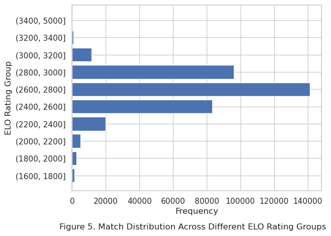

```python
match_distribution = matches['white_rating_group'].value_counts().sort_index()

# Data
intervals = match_distribution.index.to_list()
categories = [f"({interval.left}, {interval.right}]" for interval in intervals]
values = match_distribution.values

# Plot
fig, ax = plt.subplots()

# Creating the horizontal bar chart with default colors
bars = ax.barh(categories, values)

# Labels and title
ax.set_xlabel('Frequency')
ax.set_ylabel('ELO Rating Group')

plt.figtext(
    0.5, -0.05,
    'Figure 5. Match Distribution Across Different ELO Rating Groups',
    ha='center',
    fontsize=12)

# Display the plot
plt.show()
```

As expected, the distribution of matches played in chess.com shown in Figure 5 are mostly concentrated in the same ELO range identified in the Player Distribution in Figures 3 and 4. It follows that the range with the most number of players also has the most number of matches. This could be useful reference later on the result of the categorical clustering.

### Players with the Highest ELO Rating

```python
# Combine 'White' and 'Black' players' Elo ratings
all_players = pd.concat([matches[['White', 'WhiteElo']].rename(
    columns={'White': 'Player', 'WhiteElo': 'Elo'}),
    matches[['Black', 'BlackElo']].rename(
    columns={'Black': 'Player', 'BlackElo': 'Elo'})],
    ignore_index=True)

# Create a dataframe to track the highest rating for each player
highest_rating = all_players.groupby('Player')['Elo'].max().reset_index()

# Merge this information back to get the top players by their highest rating
top_players = highest_rating.sort_values(by='Elo', ascending=False).head(10)

# Display top players with their highest rating
# display(top_players)
```

**Table 2. Players with the Highest ELO Ratings**

|  | Player | ELO |
| --- | --- | --- |
| 0 | UVEK-fuuck-rules-10 | 3702.0 |
| 1 | Hikaru | 3500.0 |
| 2 | DanielNaroditsky | 3385.0 |
| 3 | MagnusCarlsen | 3369.0 |
| 4 | nihalsarin | 3350.0 |
| 5 | Oleksandr_Bortnyk | 3306.0 |
| 6 | penguingm1 | 3306.0 |
| 7 | Firouzja2003 | 3301.0 |
| 8 | AnishGiri | 3296.0 |
| 9 | CleverCrab | 3290.0 |

Table 2 shows the top players in the dataset according to ELO rating. It can be observed that the top players identified by FIDE, such as Magnus Carlsen, Hikaru Nakamura, Daniel Naroditsky, Anish Giri, to name a few, are also the top players in this list.

### Top Players per ELO Rating Range

```python
# Iterate over each rating group
for i in match_distribution.index.to_list():
    # Filter for the current rating group
    group = matches[matches['WhiteElo'] <= i.right]

    # Group by player's name and take the highest Elo within each group
    group = group.groupby('White').agg({'WhiteElo': 'max'}).reset_index()

    # Sort by rating in descending order
    group = group.sort_values(by='WhiteElo', ascending=False)

    # Display the top 5 players for the current rating group
    # display(group.head(5))

# Overall top 5 players by rating
overall_top_players = matches.groupby('White').agg(
    {'WhiteElo': 'max'}).reset_index()
overall_top_players = overall_top_players.sort_values(
    by='WhiteElo', ascending=False)
# display(overall_top_players.head(5))
```

**Table 3: Top Players in White per ELO Rating Range**

|  | White | ELO |  | White | ELO |  | White | ELO |  | White | ELO |
| --- | --- | --- | --- | --- | --- | --- | --- | --- | --- | --- | --- |
| 0 | leooadngalap | 1800.0 |  | FlameofFury | 2000.0 |  | jb2mix | 2200.0 |  | FrankieJay | 2400.0 |
| 1 | Wark1r | 1800.0 |  | flaviorcb | 2000.0 |  | Arjun2002 | 2200.0 |  | LileKoridze | 2400.0 |
| 2 | MildaLaub | 1800.0 |  | tb_12_15 | 2000.0 |  | airgun1 | 2200.0 |  | PowerThinking2650 | 2400.0 |
| 3 | retropwr | 1800.0 |  | chrysy | 2000.0 |  | Shustrick | 2200.0 |  | Viacheslav92 | 2400.0 |
| 4 | pajevic | 1800.0 |  | vsuri97 | 2000.0 |  | kmario | 2200.0 |  | LazarMilanovic | 2400.0 |
| 0 | sahist07 | 2600.0 |  | GMG | 2800.0 |  | joppie2 | 3000.0 |  | Hikaru | 3200.0 |
| 1 | Akshayraj_Kore | 2600.0 |  | dancingqueen83 | 2800.0 |  | unknown1soldier | 3000.0 |  | AnishOnYoutube | 3200.0 |
| 2 | KamilPlichta | 2600.0 |  | grnic10 | 2800.0 |  | adotand | 3000.0 |  | vi_pranav | 3200.0 |
| 3 | DanielNaroditsky | 2600.0 |  | Antipov_Mikhail_Al | 2800.0 |  | viditchess | 3000.0 |  | nihalsarin | 3200.0 |
| 4 | afgano29 | 2600.0 |  | AnthonyWirig | 2800.0 |  | abhijeetgupta1016 | 3000.0 |  | Arambai | 3200.0 |
| 0 | Hikaru | 3399.0 |  | Hikaru | 3403.0 |  | Hikaru | 3403.0 |  | Hikaru | 3403.0 |
| 1 | DanielNaroditsky | 3382.0 |  | DanielNaroditsky | 3382.0 |  | DanielNaroditsky | 3382.0 |  | DanielNaroditsky | 3382.0 |
| 2 | MagnusCarlsen | 3369.0 |  | MagnusCarlsen | 3369.0 |  | MagnusCarlsen | 3369.0 |  | MagnusCarlsen | 3369.0 |
| 3 | nihalsarin | 3348.0 |  | nihalsarin | 3348.0 |  | nihalsarin | 3348.0 |  | nihalsarin | 3348.0 |
| 4 | penguingm1 | 3303.0 |  | penguingm1 | 3303.0 |  | penguingm1 | 3303.0 |  | penguingm1 | 3303.0 |

```python
# Iterate over each rating group
for i in match_distribution.index.to_list():
    # Filter for the current rating group
    group = matches[matches['BlackElo'] <= i.right]

    # Group by player's name and take the highest Elo within each group
    group = group.groupby('Black').agg({'BlackElo': 'max'}).reset_index()

    # Sort by rating in descending order
    group = group.sort_values(by='BlackElo', ascending=False)

    # Display the top 5 players for the current rating group
    # display(group.head(5))

# Overall top 5 players by rating
overall_top_players = matches.groupby('Black').agg(
    {'BlackElo': 'max'}).reset_index()
overall_top_players = overall_top_players.sort_values(
    by='BlackElo', ascending=False)
# display(overall_top_players.head(5))
```

**Table 4: Top Players in Black per ELO Rating Range**

|  | Black | ELO |  | Black | ELO |  | Black | ELO |  | Black | ELO |
| --- | --- | --- | --- | --- | --- | --- | --- | --- | --- | --- | --- |
| 0 | DenysShapoval | 1800.0 |  | tomliujx | 2000.0 |  | TheMagician | 2200.0 |  | 731291 | 2400.0 |
| 1 | Chess_Caio2007 | 1800.0 |  | 731291 | 2000.0 |  | alishersuleymenov | 2200.0 |  | capatl | 2400.0 |
| 2 | KoOoIC | 1800.0 |  | VigneshRar | 2000.0 |  | Irina_Barchuk | 2200.0 |  | ahmad_alkhatib11 | 2400.0 |
| 3 | Hypercar | 1800.0 |  | Spasiba | 2000.0 |  | Irek_Sabirov | 2200.0 |  | Tigr86 | 2400.0 |
| 4 | srecno04 | 1800.0 |  | amintabatabaei | 2000.0 |  | IDantesI | 2200.0 |  | Dominus_et_Deus | 2400.0 |
| 0 | lucasmito | 2600.0 |  | ExceptionallyDubious | 2800.0 |  | aman | 3000.0 |  | Hikaru | 3391.0 |
| 1 | Keranke | 2600.0 |  | GMKrikor | 2800.0 |  | mishanick | 3000.0 |  | DanielNaroditsky | 3385.0 |
| 2 | Baby_Legs | 2600.0 |  | Azeryahu | 2800.0 |  | Annawel | 3000.0 |  | MagnusCarlsen | 3368.0 |
| 3 | Flawless_Fighter | 2600.0 |  | Duhless | 2800.0 |  | DanielNaroditsky | 3000.0 |  | nihalsarin | 3350.0 |
| 4 | TheBigBoss04 | 2600.0 |  | GSuguru | 2800.0 |  | spicycaterpillar | 3000.0 |  | Oleksandr_Bortnyk | 3306.0 |
| 0 | UVEK-fuuck-rules-10 | 3702.0 |  | Hikaru | 3500.0 |  | spicycaterpillar | 3200.0 |  | UVEK-fuuck-rules-10 | 3702.0 |
| 1 | Hikaru | 3500.0 |  | DanielNaroditsky | 3385.0 |  | Hikaru | 3200.0 |  | Hikaru | 3500.0 |
| 2 | DanielNaroditsky | 3385.0 |  | MagnusCarlsen | 3368.0 |  | nihalsarin | 3200.0 |  | DanielNaroditsky | 3385.0 |
| 3 | MagnusCarlsen | 3368.0 |  | nihalsarin | 3350.0 |  | Firouzja2003 | 3200.0 |  | MagnusCarlsen | 3368.0 |
| 4 | nihalsarin | 3350.0 |  | Oleksandr_Bortnyk | 3306.0 |  | Arambai | 3200.0 |  | nihalsarin | 3350.0 |

### Insights

The analysis and filtering reveal the top White and Black players in each ELO rating group for both White and Black, as shown in Tables 3 and 4, respectvely. This ensures that names do not repeat within the same rating if the rating value is identical. Here are the key insights derived from the updated dataset:

These insights reflect a structured and clear understanding of player distribution and performance within the dataset, allowing for a focused analysis of top players and their progression.

### Win Distribution

Figure 6 shows the distribution of match results within the dataset, including draws (`1/2-1/2`), White wins (`1-0`), and Black wins (`0-1`).

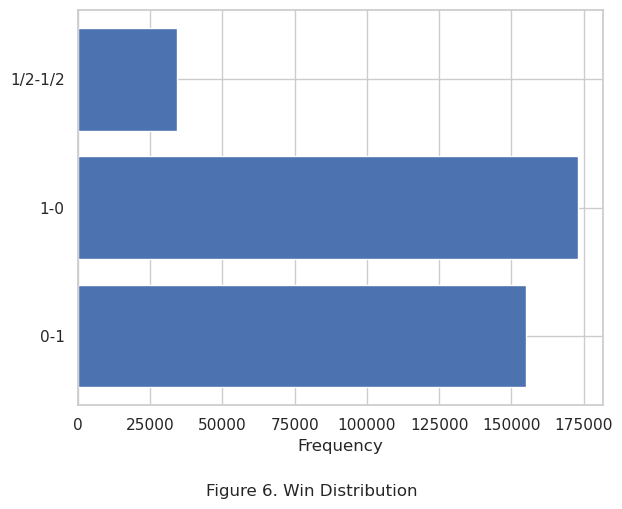

```python
fig, ax = plt.subplots()

# Data
result_distribution = (
    matches['Result'].value_counts().sort_index())
results = result_distribution.index.tolist()
values = result_distribution.values

# Creating the horizontal bar chart
bars = ax.barh(
    results, values)

# Labels and title
ax.set_xlabel('Frequency')

# Adding the plot title at the bottom center
plt.figtext(0.5, -0.05, 'Figure 6. Win Distribution',
            ha='center',
            fontsize=12)

# Adjust layout to ensure labels are not cropped
plt.tight_layout()

# Display the plot
plt.show()
```

**Results**:

- The graph displays three possible outcomes: `1/2-1/2` (draw), `1-0` (White wins), and `0-1` (Black wins).

**Frequency**:

- Draws (`1/2-1/2`): This outcome has the lowest frequency, indicating that fewer games end in a draw compared to wins.
- White wins (`1-0`): This outcome has the highest frequency, suggesting that White wins are more common in the dataset.
- Black wins (`0-1`): This outcome also has a high frequency but is slightly less common than White wins.

We can infer from the graph that:

1. *White Wins More Often*: The dataset shows that White wins more often than Black, which aligns with the general chess principle that White, having the first move, tends to have a slight advantage.
2. *Draws are Less Common*: The relatively lower number of draws indicates that most games in the dataset end with a decisive result.
3. *Balanced Wins*: Despite White winning more often, the number of Black wins is also substantial, indicating a competitive balance in the games.

### Most Commonly Used Chess Openings (ECOs)

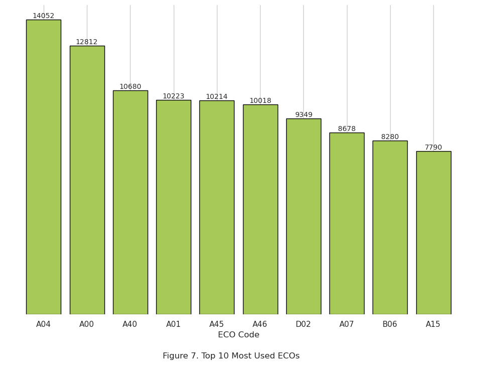

```python
# Get the top 10 most popular openings
top_openings = matches['ECO'].value_counts().head(10)

# Create a bar chart
plt.figure(figsize=(12, 8))
bars = plt.bar(top_openings.index,
               top_openings.values,
               color='#A7C957',
               edgecolor='black')

# Add labels and title
plt.xlabel('ECO Code')
plt.ylabel('Number of Games')

# Adding the plot title at the bottom center
plt.figtext(0.5, 0, 'Figure 7. Top 10 Most Used ECOs',
            ha='center',
            fontsize=12)

# Add data labels to each bar
for bar in bars:
    yval = bar.get_height()
    plt.text(bar.get_x() + bar.get_width() / 2,
             yval, int(yval),
             ha='center',
             va='bottom',
             fontsize=10)

# Hide y-axis and remove the box
plt.gca().spines['top'].set_visible(False)
plt.gca().spines['right'].set_visible(False)
plt.gca().spines['left'].set_visible(False)
plt.gca().spines['bottom'].set_visible(False)
plt.gca().yaxis.set_visible(False)

# Show the plot
plt.show()
```

In Figure 7, we can observe that the most used ECOs (Encyclopaedia of Chess Openings codes) are:

- **A04(Reti Opening)**: The most used ECO code with a count of 14,052. This indicates it is the most popular opening strategy among players.
- **A00(Uncommon Opening)**: The second most used ECO code with a count of 12,812, showing its significant popularity.
- **A40(Queen's Pawn Opening)**: This code has a usage count of 10,680, making it the third most favored opening.
- **A01(Nimzowitsch-Larsen Attack)**: With a count of 10,223, this ECO code is also highly used.
- **A45(Trompowsky Attack)**: This opening has been used 10,214 times.
- **A46(Indian Game)**: Slightly behind A45, with a count of 10,018.
- **D02(Queen's Pawn Game)**: This code has a usage count of 9,349.
- **A07(King's Indian Attack)**: Used 8,678 times, showing its relevance in players' strategies.
- **B06(Robatsch (Modern) Defense)**: This code has been used 8,280 times.
- **A15(English Opening)**: The tenth most used ECO code with a count of 7,790.

The presence of multiple ECO codes with high usage counts (ranging from 7,790 to 14,052) indicates a diversity of preferred opening strategies among players. This variety suggests that different players or contexts may favor different openings based on their playstyle or specific scenarios.

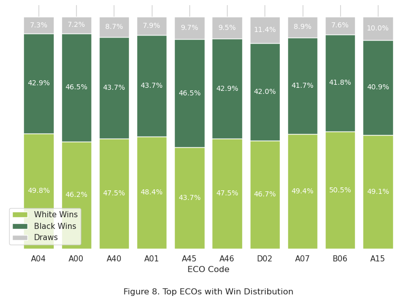

```python
# Get the top 10 most popular ECO codes
top_eco = matches['ECO'].value_counts().head(10).index
top_eco_data = matches[matches['ECO'].isin(top_eco)]

# Calculate frequencies for the top 10 ECO codes
eco_frequencies = top_eco_data['ECO'].value_counts().loc[top_eco].values

# Calculate percentages for each ECO code
white_win_percent = []
black_win_percent = []
draw_percent = []

for eco in top_eco:
    total_games = top_eco_data[top_eco_data['ECO'] == eco].shape[0]
    white_wins = (
        top_eco_data[(top_eco_data['ECO'] == eco) & (
            top_eco_data['Result'] == '1-0')].shape[0])
    black_wins = (
        top_eco_data[(top_eco_data['ECO'] == eco) & (
            top_eco_data['Result'] == '0-1')].shape[0])
    draws = (
        top_eco_data[(top_eco_data['ECO'] == eco) & (
            top_eco_data['Result'] == '1/2-1/2')].shape[0])

    white_win_percent.append((white_wins / total_games) * 100)
    black_win_percent.append((black_wins / total_games) * 100)
    draw_percent.append((draws / total_games) * 100)

# Create a figure
plt.figure(figsize=(10, 6))

# Plot stacked bars with updated colors
bar1 = plt.bar(
    top_eco,
    white_win_percent,
    color='#A7C957',
    label='White Wins')

bar2 = plt.bar(
    top_eco,
    black_win_percent,
    bottom=white_win_percent,
    color='#4A7C59',
    label='Black Wins')

bar3 = plt.bar(
    top_eco,
    draw_percent,
    bottom=np.array(white_win_percent) + np.array(black_win_percent),
    color='#C8C8C8',
    label='Draws')

# Add labels and title
plt.xlabel('ECO Code')
plt.ylabel('Percentage')
plt.legend()

# Adding the plot title at the bottom center
plt.figtext(0.5, -0.05, 'Figure 8. Top ECOs with Win Distribution',
            ha='center',
            fontsize=12)

# Add labels as percentages
add_percentage_labels(bar1, white_win_percent)
add_percentage_labels(bar2, black_win_percent)
add_percentage_labels(bar3, draw_percent)

# Hide y-axis and remove the box
plt.gca().spines['top'].set_visible(False)
plt.gca().spines['right'].set_visible(False)
plt.gca().spines['left'].set_visible(False)
plt.gca().spines['bottom'].set_visible(False)
plt.gca().yaxis.set_visible(False)

# Adjust layout to remove margins
plt.subplots_adjust(left=0.1, right=0.9, top=0.9, bottom=0.1)

# Display the plot
plt.show()
```

In Figure 8, the win distribution for the most used ECOs is shown. Each bar represents the percentage of wins by white, wins by black, and draws for each ECO code.

1. **A04 (Reti Opening)**
   - White Wins: 49.8%
   - Black Wins: 42.9%
   - Draws: 7.3%
2. **A00 (Uncommon Opening)**
   - White Wins: 46.2%
   - Black Wins: 46.5%
   - Draws: 7.2%
3. **A40 (Queen's Pawn Opening)**
   - White Wins: 47.5%
   - Black Wins: 43.7%
   - Draws: 8.7%
4. **A01 (Nimzowitsch-Larsen Attack)**
   - White Wins: 48.4%
   - Black Wins: 43.7%
   - Draws: 7.9%
5. **A45 (Trompowsky Attack)**
   - White Wins: 43.7%
   - Black Wins: 46.5%
   - Draws: 9.7%
6. **A46 (Indian Game)**
   - White Wins: 47.5%
   - Black Wins: 42.9%
   - Draws: 9.5%
7. **D02 (Queen's Pawn Game)**
   - White Wins: 46.7%
   - Black Wins: 42.0%
   - Draws: 11.4%
8. **A07 (King's Indian Attack)**
   - White Wins: 49.4%
   - Black Wins: 41.7%
   - Draws: 8.9%
9. **B06 (Robatsch (Modern) Defense)**
   - White Wins: 50.5%
   - Black Wins: 41.8%
   - Draws: 7.6%
10. **A15 (English Opening)**
    - White Wins: 49.1%
    - Black Wins: 40.9%
    - Draws: 10.0%

These statistics provide insights into the performance of each opening strategy, with some openings showing a higher win rate for white, others for black, and varying rates of draws.

### Drop Additional Features

```python
matches_for_clustering = matches.copy()
columns_for_removal = ['White', 'Black', 'WhiteElo', 'BlackElo', 'Date']
matches_for_clustering.drop(columns=columns_for_removal, inplace=True)
```

#### Justifications to Remove These Additional Features

1. White and Black: Removing player identifiers is appropriate as they do not contribute to the clustering process.
2. WhiteElo and BlackElo: These are already represented by the white_rating_group and black_rating_group columns, so it's logical to remove them.
3. Date: The date of the match is not relevant for clustering based on player performance and ratings.

```python
matches_for_clustering
```

|  | Result | ECO | Opening | white_rating_group | black_rating_group |
| --- | --- | --- | --- | --- | --- |
| 13 | 1-0 | D02 | Queens-Pawn-Opening-Zukertort-Variation-2...c6... | (1600, 1800] | (1600, 1800] |
| 17 | 1-0 | A41 | Queens-Pawn-Opening-Anglo-Slav-Opening-3.Nc3 | (1600, 1800] | (1600, 1800] |
| 25 | 1-0 | B07 | Pirc-Defense-2.d4 | (1600, 1800] | (1600, 1800] |
| 26 | 1-0 | D00 | Queens-Pawn-Opening-1...d5-2.e3 | (1600, 1800] | (1600, 1800] |
| 27 | 0-1 | A41 | Queens-Pawn-Opening-1...d6-2.c4-Nd7 | (1600, 1800] | (1600, 1800] |
| ... | ... | ... | ... | ... | ... |
| 376326 | 1-0 | D07 | Queens-Gambit-Declined-Chigorin-Main-Line...8.... | (3000, 3200] | (2800, 3000] |
| 376327 | 1-0 | D00 | Queens-Pawn-Opening-Accelerated-London-System-... | (2800, 3000] | (3000, 3200] |
| 376328 | 1-0 | D02 | Queens-Pawn-Opening-Zukertort-Chigorin-Variation | (3000, 3200] | (2800, 3000] |
| 376329 | 1-0 | B90 | Sicilian-Defense-Open-Najdorf-Variation-6.Bd3 | (3000, 3200] | (3000, 3200] |
| 376330 | 0-1 | D55 | Queens-Gambit-Declined-Neo-Orthodox-Variation | (3000, 3200] | (3000, 3200] |

362281 rows × 5 columns

#### Remaining Features for Categorical Clustering

- Result: The outcome of the match (e.g., "1-0", "0-1", "1/2-1/2").
- ECO: The Encyclopaedia of Chess Openings code, representing the opening used.
- Opening: A detailed description of the opening.
- white_rating_group: The rating group for the White player.
- black_rating_group: The rating group for the Black player.

## Categorical Clustering Using K-Modes

Categorical clustering using k-modes is a technique used to group a set of data objects into a specified number of clusters based on their categorical attributes. The k-modes algorithm is an extension of the standard k-means clustering algorithm, but it is designed specifically for categorical data. Instead of using means to represent cluster centers, k-modes uses modes, which are the most frequent categorical values in each cluster. This ensures that the clustering process converges to a local minimal result. K-modes is particularly useful for high-dimensional categorical data, where the standard k-means algorithm may not perform well due to the Euclidean distance function and the use of means to represent cluster centers.The k-modes algorithm has been widely used in various applications, including data mining and commercial software [[8]](https://www.irma-international.org/viewtitle/10828/?isxn=9781605660103).

```python
# Define the range of k values
ks = list(range(2, 10))
```

```python
# Parameters: df for clustering, no of samples
# Returns array of cost
kmodes_cost = calculate_cost(matches_for_clustering, 10000)
```

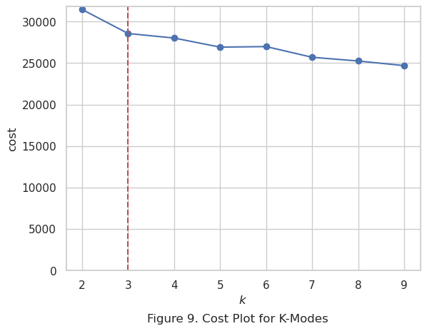

```python
# Plot Costs
plot_costs(kmodes_cost, 3, 9)
```

In Figure 9, the cost plot for **K-Modes** shows how the total cost varies with different numbers of clusters (k). The dashed red line at $ k = 3 $ indicates a significant point in the plot:

1. **Elbow Method**: The curve appears to bend at $ k = 3 $, suggesting this as the "elbow point." This is a common method to choose the optimal number of clusters by selecting the point where the rate of decrease sharply shifts. Here, increasing the number of clusters beyond 3 leads to smaller reductions in cost, implying diminishing returns in terms of clustering efficiency.
2. **Cost Reduction**: There is a notable drop in cost when increasing from 2 to 3 clusters, but subsequent increases in $ k $ (from 3 to 4 and beyond) show less dramatic cost reductions. This suggests that three clusters are sufficient to capture the significant structure of the data without incurring unnecessary complexity from more clusters.
3. **Interpretability and Manageability**: With $ k = 3 $, the model remains simpler and more interpretable while adequately reducing the cost associated with the K-Modes algorithm. More clusters might complicate the model and reduce its practical usability, especially when the additional clusters don't contribute significantly to lowering the overall cost.

Thus, $ k = 3 $ appears to be the best value for $ k $ due to these reasons, making it a practical choice for achieving effective clustering while maintaining manageability and interpretability of the model.

```python
# Creates clusters and returns df with clusters
km = KModes(3)
df_clusters_kmodes = create_df_clusters(km, matches_for_clustering)
```

```python
# km.cluster_centroids_
```

```python
# print_stats_per_cluster(df_clusters_kmodes, 5)
```

## Resulting Clusters

Using categorical clustering (k-modes), the model has identified the following clusters:

#### Cluster 1

- **Result Distribution**:
  - **Total Matches**: 75,211
  - **Most Common Result**: `0-1` (Black wins, 47,430 matches)
- **Top 5 ECO Codes**:
  1. **D30 (Queen's Gambit Declined)**: 2,761 matches
  2. **A46 (Queen's Pawn)**: 2,226 matches
  3. **A45 (Queen's Pawn)**: 2,147 matches
  4. **A40 (Queen's Pawn)**: 1,950 matches
  5. **A01 (Nimzowitsch-Larsen Attack)**: 1,770 matches

#### Cluster 2

- **Result Distribution**:
  - **Total Matches**: 186,613
  - **Most Common Result**: `1-0` (White wins, 124,025 matches)
- **Top 5 ECO Codes**:
  1. **A04 (Reti Opening)**: 11,234 matches
  2. **A00 (Irregular Opening)**: 5,710 matches
  3. **A15 (English Opening)**: 5,574 matches
  4. **A40 (Queen's Pawn)**: 5,477 matches
  5. **A01 (Nimzowitsch-Larsen Attack)**: 5,451 matches

### Initial Insights

These clusters will be analyzed and discussed in further detail in the Results and Discussion Section of this paper.

The clustering analysis on the entire dataset inadvertently showcased strategic patterns observed among players with higher ratings, within the 2400 to 3000 ELO range. This is due to the dataset's imbalance, being dominated with matches involving these top-tier players. The team recognized the need to perform a more targeted approach, specifically tailoring a clustering analysis on the lower rating group, within the 1600 to 2400 ELO range. By narrowing our scope to this demographic, we endeavor to delve deeper into their strategies, particularly concerning opening moves. Our aim is to identify the most prevalent and effective strategies within this rating range, thereby providing valuable insights that can aid these players in refining their gameplay and advancing their chess skills.

## Targeted Clustering on ELO Rating Group 1600 - 2400

Targeted clustering of ELO ratings between 1600 and 2400 can be highly beneficial for understanding and segmenting player behaviors and skills within this specific skill range. This range typically includes players who have moved beyond beginner levels and are refining their strategies and techniques at intermediate to advanced stages. Players within the 1600 to 2400 ELO range exhibit significant variations in skill and strategy sophistication. Clustering these players can help identify subgroups with similar playing styles, strengths, and weaknesses, which can be invaluable for tailored coaching, match-making, and player development.

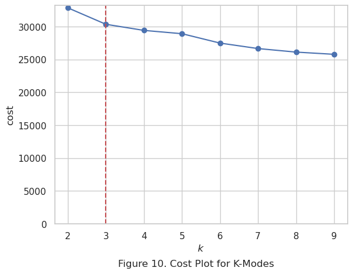

```python
matches_by_rating_group = matches.copy()

# Create a bin for the specific Elo rating range 1600-2400
matches_by_rating_group['white_rating_group2'] = (
    pd.cut(matches['WhiteElo'], bins=[1600, 2400]))
matches_by_rating_group['black_rating_group2'] = (
    pd.cut(matches['BlackElo'], bins=[1600, 2400]))

m_by_rating_for_cluster = matches_by_rating_group.copy()
columns_for_removal = ['White', 'Black', 'WhiteElo', 'BlackElo', 'Date']
m_by_rating_for_cluster.drop(columns=columns_for_removal, inplace=True)

rating_groups = {}

for group, group_df in m_by_rating_for_cluster.groupby('white_rating_group2'):
    rating_groups[f'{str(group)}_White'] = group_df.drop(
        columns=['white_rating_group2', 'black_rating_group2'])

for group, group_df in m_by_rating_for_cluster.groupby('black_rating_group2'):
    rating_groups[f'{str(group)}_Black'] = group_df.drop(
        columns=['white_rating_group2', 'black_rating_group2'])

# Combine 1600-2400 rating group data for both white and black
combined_ratings = pd.concat(
    [rating_groups['(1600, 2400]_White'],
     rating_groups['(1600, 2400]_Black']],
    ignore_index=True)

unique_ratings = combined_ratings.drop_duplicates()
rating_groups['(1600, 2400]_Combined'] = unique_ratings

# Further clustering steps
matches_for_clustering_1600_2400 = rating_groups['(1600, 2400]_Combined']

kmodes_cost_1600_2400 = calculate_cost(
    matches_for_clustering_1600_2400, 10000)
plot_costs(kmodes_cost_1600_2400, 3, 10)

# Creates clusters and returns df with clusters
km_1600_2400 = KModes(3)
df_clusters_kmodes_1600_2400 = create_df_clusters(
    km_1600_2400, matches_for_clustering_1600_2400)

# print_stats_per_cluster(df_clusters_kmodes_1600_2400)
```

In Figure 10, the cost plot for K-Modes shows how the total cost varies with different numbers of clusters (k). The dashed red line at $ k = 3 $ again marks a significant point on this plot, though the characteristics slightly differ from the previous cluster:

1. **Elbow Method**: Unlike in the previous plot, the elbow point at $ k = 3 $ here is less pronounced but still observable. The plot shows a gradual decrease in cost as $ k$ increases from 2 to 3, indicating that the benefit of adding more clusters beyond 3 diminishes.
2. **Rate of Decrease**: The decrease in cost from $ k = 2 $ to $ k = 3 $ is notable but less steep compared to the other plot. Beyond $ k = 3 $, the rate of cost reduction slows down considerably, suggesting less value in adding more clusters. This plateauing effect indicates that increasing $ k$ beyond 3 contributes minimal improvements in clustering effectiveness.
3. **Practical Implications**: Choosing $ k = 3 $ allows for a balance between computational efficiency and sufficient granularity in the data segmentation. The smaller drops in cost with higher $ k $ values may not justify the complexity of managing more clusters.
4. **Stability and Interpretability**: With $ k = 3 $, the model retains stability and interpretability. Additional clusters might complicate the model without significant gains in performance, making $ k = 3 $ a practical choice for both simplicity and effectiveness.

Overall, $ k = 3 $ in Figure 10 is suggested as the optimal number of clusters for the K-Modes algorithm based on this cost efficiency analysis. This number strikes a reasonable compromise between capturing the essential data structure and avoiding overfitting with too many clusters.

## Resulting Clusters for Targeted Clustering

After using categorical clustering (k-modes) on matches within ELO 1600-2400, the model has identified the following clusters:

#### Cluster 1

- **Result Distribution**:
  - **Total Matches**: 17,859
  - **Most Common Result**: `1-0` (White wins, 14,127 matches)
- **Top 5 ECO Codes**:
  1. **A00 (Irregular Opening)**: 817 matches
  2. **A46 (Queen's Pawn)**: 414 matches
  3. **A45 (Queen's Pawn)**: 406 matches
  4. **B01 (Caro-Kann Defense)**: 381 matches
  5. **B07 (Pirc Defense)**: 355 matches

#### Cluster 2

- **Result Distribution**:
  - **Total Matches**: 9,161
  - **Most Common Result**: `0-1` (Black wins, 8,538 matches)
- **Top 5 ECO Codes**:
  1. **A40 (Queen's Pawn)**: 499 matches
  2. **A45 (Queen's Pawn)**: 287 matches
  3. **C00 (French Defense)**: 193 matches
  4. **A46 (Queen's Pawn)**: 181 matches
  5. **B06 (Robatsch Defense)**: 169 matches

#### Cluster 3

- **Result Distribution**:
  - **Total Matches**: 3,349
  - **Most Common Result**: `0-1` (Black wins, 2,692 matches)
- **Top 5 ECO Codes**:
  1. **A04 (Reti Opening)**: 390 matches
  2. **A45 (Queen's Pawn)**: 78 matches
  3. **A46 (Queen's Pawn)**: 74 matches
  4. **B07 (Pirc Defense)**: 68 matches
  5. **B01 (Caro-Kann Defense)**: 63 matches

### Initial Insights

1. **Cluster 1**:
   - Dominated by White wins with the `A00 (Irregular Opening)`.
   - A lot of players prefer unorthodox strategy characterized by with irregular openings.
2. **Cluster 2**:
   - Dominated by Black wins with the `A40 (Queen's Pawn)`.
   - A lot of players use variations of the Queens Pawn opening, highlighting their preference for classical openings.
3. **Cluster 3**:
   - Also dominated by Black wins with the `A04 (Reti Opening)`.
   - A lot of players prefer hypermordern opening style with the dominance of Reti opening.

These clusters will be analyzed and discussed in further detail in the Results and Discussion Section of this paper.

## Results and Discussion

This project aimed to decode chess strategies by clustering chess openings based on a dataset scraped from chess.com. It focused on several categorical features, including the match result, ECO code, specific chess opening, and the ELO ratings of the players. We performed categorical clustering on the entire dataset, binning ELO ratings every 200 points, to uncover patterns and strategies used at different skill levels. Here, we present and discuss the clusters formed from our analysis.

## Clustering of Matches for the Entire Dataset

### Cluster 1: Black's Defensive Grounds

ELO Rating of Most Players in the Cluster: 2400-2600

- **Top ECO Codes** (Refer to Figure 11 for details):
  - D30 (Queen's Gambit Declined)
  - A46 (Queen's Pawn Game)
  - A45 (Queen's Pawn Game)
  - A40 (Queen's Pawn)
  - A01 (Nimzowitsch-Larsen Attack)
- **Why These Openings Clustered Together:**
  - Strategic Defense: Openings like D30 and A46 are known for their strong defensive characteristics, helping players neutralize aggressive moves from their opponents.
  - Positional Play: Emphasis on controlling the board and preparing for counter-attacks.
- **Key Insights:**
  - Balanced Play: While Figure 12 shows that this cluster has more wins for black, the top openings identified provide opportunities for both defensive and offensive maneuvers, making them versatile for players.
  - Strong Defense: High success rate for black, showcasing effective defensive strategies that can transition into counter-attacks.

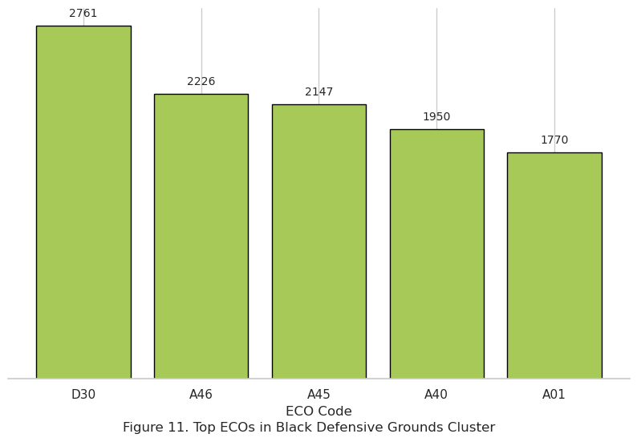

```python
plot_top_eco_codes(2, 'Figure 11. Top ECOs in Black Defensive Grounds Cluster')
```

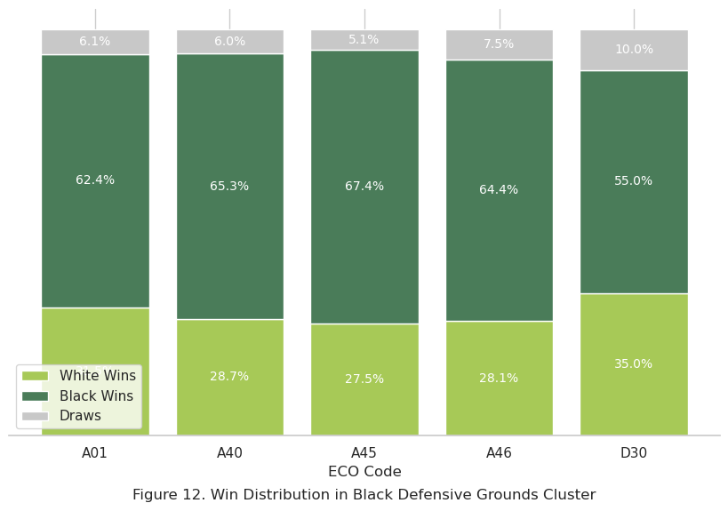

```python
plot_win_distribution(
    2, 'Figure 12. Win Distribution in Black Defensive Grounds Cluster')
```

### Cluster 2: Mid-Rated White Dominance

ELO Rating of Most Players in the Cluster: 2600-2800

- **Top ECO Codes** (Refer to Figure 13 for details):
  - A04 (Reti Opening)
  - A00 (Irregular Opening)
  - A15 (English Opening)
  - A40 (Queen's Pawn)
  - A01 (Nimzowitsch-Larsen Attack)
- **Why These Openings Clustered Together**:
  - Aggressive Play: Openings such as A04 and A15 are favored for their aggressive starting positions, enabling white to control the center early.
  - Flexibility: These openings allow for a wide range of strategies and adaptations.
  - Control: Emphasis on controlling the center and rapid piece development.
- **Key Insights**:
  - White Dominance: As seen in Figure 14, this cluster is dominated with a high frequency of white wins due to strong opening positions that leverage white's first-move advantage.
  - Strategic Depth: The openings offer deep strategic possibilities, making them popular among mid-rated players who seek both aggression and flexibility.

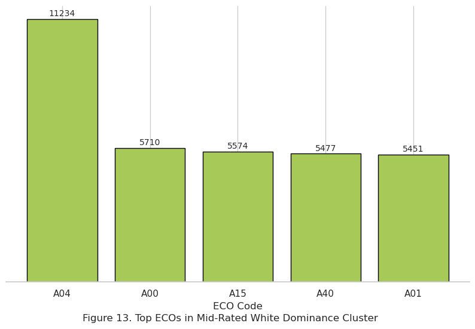

```python
plot_top_eco_codes(
    0, 'Figure 13. Top ECOs in Mid-Rated White Dominance Cluster')
```

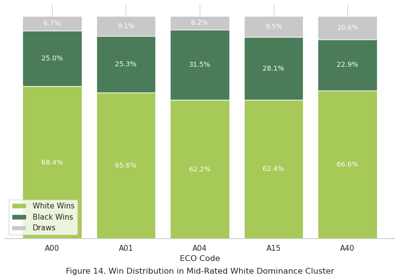

```python
plot_win_distribution(
    0, 'Figure 14. Win Distribution in Mid-Rated White Dominance Cluster')
```

### Cluster 3: High-Rated Black Counters

ELO Rating of Most Players in the Cluster: 2800-3000

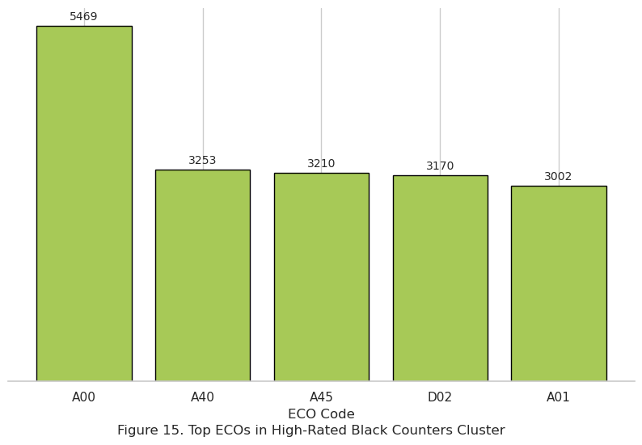

```python
plot_top_eco_codes(
    1, 'Figure 15. Top ECOs in High-Rated Black Counters Cluster')
```

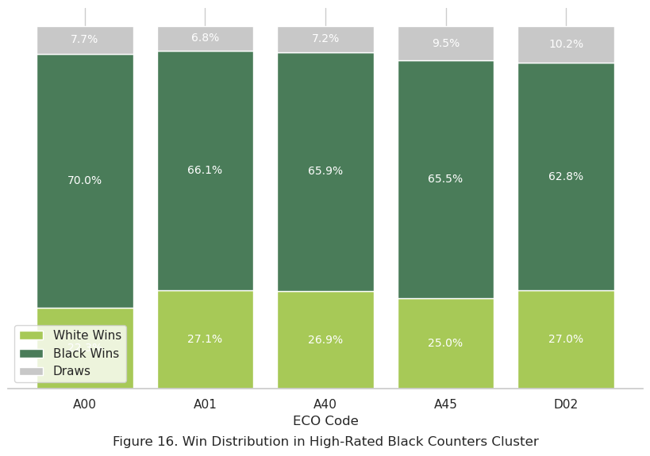

```python
plot_win_distribution(
    1, 'Figure 16. Win Distribution in High-Rated Black Counters Cluster')
```

While comprehensive, the clustering analysis of the entire dataset inadvertently reflected the characteristics of the higher rating groups due to the data's imbalance, where majority of the matches involved players with ELOs between 2400-3000. Consequently, the insights for the 1600-2400 ELO rating range, which are highly relevant to many, including club and class players, were not as thoroughly explored. As mentioned in the implementation, to address this gap, we decided to conduct a targeted analysis for the ELO rating group of 1600-2400. This approach allows us to explore the most effective and popular openings among players in this ELO rating range, providing insights that can help them improve their game.

## Targeted Clustering of Matches for ELO 1600-2400

### Cluster 1: Versatile Strategies

- **Top ECO Codes**:
  - A00 (Irregular Opening)
  - A46 (Queen's Pawn Game)
  - A45 (Queen's Pawn Game)
  - B01 (Caro-Kann Defense)
  - B07 (Pirc Defense)
- **Why These Openings Clustered Together**:
  - Aggressive Play: Openings characterized by active and dynamic strategies.
  - Flexibility: Multiple strategic options are available, allowing players to adapt to various situations.
  - Control: Emphasis on center control, which is crucial for a successful opening phase.
- **Key Insights**:
  - White Dominance: Frequent white wins due to the aggressive and versatile nature of these openings.
  - Adaptability: These openings allow easy transitions into different game plans based on the opponent's moves.
  - Strategic Depth: A balance between aggressive and defensive plays, providing players with robust options.

### Cluster 2: Black’s Balanced Defense

- **Top ECO Codes**:
  - A40 (Queen's Pawn)
  - A45 (Queen's Pawn Game)
  - C00 (French Defense)
  - A46 (Queen's Pawn)
  - B06 (Robatsch Defense)
- **Why These Openings Clustered Together**:
  - Strategic Defense: Openings designed to neutralize aggressive plays from white.
  - Positional Play: Focus on controlling the board and preparing for counter-attacks.
  - Solid Structures: Lead to balanced midgame positions that can be exploited.
- **Key Insights**:
  - Black Wins: High success rate for black, showcasing effective defensive strategies.
  - Gradual Control: These openings help neutralize white's first-move advantage and gradually shift the balance.

### Cluster 3: Black Counters

- **Top ECO Codes**:
  - A04 (Reti Opening)
  - A45 (Queen's Pawn)
  - A46 (Queen's Pawn)
  - B07 (Pirc Defense)
  - B01 (Caro-Kann Defense)
- **Why These Openings Clustered Together**:
  - Defensive Play: Strong defensive setups that provide a solid foundation against white's opening moves.
  - Counter-Attack Potential: These openings create opportunities for black to counter-attack and exploit white's weaknesses.
  - Flexibility: A wide range of responses and strategic options are available.
- **Key Insights**:
  - Black Wins: High success rate for black, demonstrating the effectiveness of these openings in counter-attacking.
  - Balanced Play: These openings offer opportunities for both defensive and offensive maneuvers, making them versatile tools in a player’s strategy.

The clustering results reveal distinct strategies and preferences among chess players at different ELO ratings. Higher-rated players (2400+) tend to employ sophisticated, balanced strategies that allow for both defense and counter-attacks. In contrast, players in the 1600-2400 Elo range favor more flexible and aggressive openings that focus on rapid control of the center and strategic adaptability.

Overall, this study provides valuable insights into the strategic underpinnings of chess openings and their impact on gameplay. By understanding these patterns, players can refine their opening repertoire to better suit their skill level and strategic preferences, ultimately enhancing their performance in competitive play.

## Conclusion

The primary challenge addressed in this study is that many chess players tend to rely on a limited set of familiar opening moves, which can impede their strategic growth and adaptability. This restriction affects individual performance and reduces overall diversity and competitiveness within the chess community. By employing categorical data clustering techniques, our goal was to uncover patterns in chess openings and suggest novel and effective moves tailored to players' styles and preferences. This approach aims to enhance strategic variety, promote continuous learning, and elevate the overall standard of play in the chess community.

Through our analysis, we identified distinct clusters of openings based on player ELO ratings, providing insights into the strategic preferences and effectiveness of various openings across different skill levels. Our findings reveal that higher-rated players tend to favor balanced strategies with a strong emphasis on defense and counterattacks, while mid-rated players exhibit a preference for aggressive and flexible openings that allow for rapid control of the center.

By understanding these patterns, players can refine their opening game plan to better suit their skill level and strategic preferences. This, in turn, can lead to significant improvements in their game, fostering a more competitive and dynamic chess environment.

#### *Play Style Differences*

Our analysis distinguished clear differences in play styles between higher-rated players (ELO 2400+) and those in the 1600-2400 range:

- **ELO 2400+ Clusters:** These clusters reflect a balanced approach, with openings that provide solid defensive capabilities and opportunities for counter-attacks. The sophisticated strategies in these clusters highlight the importance of tactical depth and adaptability.
- **ELO 1600-2400 Clusters:** These clusters emphasize aggressive play and robust defensive strategies tailored to mid-level players. The focus is on rapid control of the center and the ability to adapt strategies dynamically based on the opponent’s moves.

#### *Why It Matters*

The insights gained from this study have practical implications for chess players aiming to improve their game:

- **Skill Development:** Understanding the prevalent openings and strategies at various skill levels can help players focus on key areas for improvement. For instance, players rated around 1600 should work on developing solid pawn structures and enhancing their positional play to advance to higher levels.
- **Adaptability:** Recognizing common strategies used by players at different ELO ratings prepares individuals to face a wide range of opponents, enhancing their ability to achieve consistent success in competitive play.
- **Strategic Depth:** Observing the sophisticated strategies employed by higher-rated players provides valuable lessons for lower-rated players. By studying these advanced tactics, mid-level players can develop more complex and effective game plans.

This project has successfully decoded chess strategies by clustering chess openings, providing a clear view of how different openings are utilized across various skill levels. Our analysis reveals that while high-rated players prefer a balanced and versatile approach, mid-level players favor aggressive and adaptable strategies. The recurrence of certain ECO codes across different clusters underscores the universal appeal and effectiveness of these openings.

By focusing on the identified strategies and improving key areas, players can enhance their gameplay and advance their skills. This study not only provides a roadmap for players seeking to refine their opening set of moves but also contributes to the broader understanding of chess strategy development. Future research could further explore these patterns with larger datasets and more granular clustering methods, potentially uncovering even deeper insights into the strategic complexities of chess.

## Limitations of the Study

The team recognizes and acknowledges several limitations that may have influenced the results and recommendations:

- **Sample Size and Representativeness**  
  The analysis was based on a dataset from chess.com, which, while extensive, may not capture the full diversity of global chess players. The sample may be biased towards more active online players, potentially skewing the findings.
- **ELO Range Focus** The targeted analysis focused on players within the 1600-2400 and 2400-3000 ELO range, which may not fully represent strategies effective for players outside this range. Additional data for those on lower ELO ratings would provide additional insights on the chess openings used by beginners or casual players.
- **Categorical Clustering Limitations** The clustering methodology was primarily categorical, which might oversimplify the complex nature of chess strategies. More sophisticated clustering techniques could provide deeper insights such as considering numerical features and performing mixed clustering on the dataset.
- **Exclusion of Predictive Models** The study focused on clustering and did not employ predictive models that could forecast future trends in chess strategy. Integrating predictive analytics could offer additional valuable insights.
- **Limited Contextual Factors** Factors such as players’ psychological states, time control of the games, and environmental conditions were not considered, which might affect the generalizability of the findings.

## References

[[1] Chess.com. (2020) How Popular is Chess?](https://www.chess.com/news/view/how-popular-is-chess-8306)

[[2] FIDE. (2020) World Statistics Day - Chess Touch.](https://www.fide.com/news/782)

[[3] Business Standard. (2024) FIDE opens bidding process for World Championship, sets budget of $9.6 mn.](https://www.business-standard.com/sports/other-sports-news/fide-opens-bidding-process-for-world-championship-sets-budget-of-9-6-mn-124042700604_1.html)

[[4] Chess.com. (2022) Chess.com Reaches 100 Million Members!](https://www.chess.com/article/view/chesscom-reaches-100-million-members)

[[5] ESports GG. (2023) Chess.com crashes as it hits highest-ever daily active users.](https://esports.gg/news/chess/chess-com-crashes-as-it-hits-the-highest-ever-daily-active-users/)

[[6] Chess.com (2022) All the chess titles and how to acquire them](https://www.chess.com/blog/praharshkstudios/all-the-chess-titles-and-how-to-acquire-them#:~:text=There%20are%208%20official%20chess%20titles%20awarded%20to,CM%2C%20FM%2C%20IM%20and%20GM%20in%20that%20order.)

[[7] 365chess.com ECO Codes](https://www.365chess.com/eco.php)

[[8] Clustering Categorical Data with K-modes](https://www.irma-international.org/viewtitle/10828/?isxn=9781605660103)

[[9] Chess.com API](https://www.chess.com/news/view/published-data-api)